# Zobrazení dat o policii

## Popis dat

Pracujeme s datovou maticí 50x6, která zachycuje měření reakčního času příslušníků policie. Vedle samotné rychlosti reakce jsou pak zaznamenány některé veličiny popisující fyzický stav každého policisty. Jsou jimi výška, váha, podíl tuku v těle, puls a tlak během měření (předpokládám).

## Prozkoumání a zobrazení dat

Začneme načtením a přípravou dat. Přídáme znak, který policisty dělí na rychlé a pomalé pro pozdější použití při vykreslování.

Vycházíme přitom z předpokládané reálné situace, kdy nás budou především zajímat závislosti mezi reakční dobou a ostatními veličinami. Chceme tedy aby tento vztah byl z dat co nejlépe patrný.

Speciálně si rovnou připravíme standardizovanou matici.

```python
import pandas as pd

df = pd.read_csv('police.txt', delimiter='[ \t]+', engine='python')
normalized_df = (df - df.mean()) / df.std()
df['is_fast'] = df['react'] < df.mean()['react']
normalized_df['is_fast'] = df['react'] < df.mean()['react']
```

Začneme zobrazením základních popisných statistik. Tedy zobrazením výběrových průměrů, směrodatných odchylek a základních kvantilů jednotlivých veličin.

```python
df.describe()
```

|  | react | height | weight | fat | pulse | diast |
| --- | --- | --- | --- | --- | --- | --- |
| count | 50.000000 | 50.000000 | 50.00000 | 50.000000 | 50.000000 | 50.000000 |
| mean | 0.316200 | 178.106000 | 78.35240 | 13.782400 | 73.080000 | 74.600000 |
| std | 0.048215 | 7.024081 | 11.46837 | 7.347631 | 12.910745 | 8.113984 |
| min | 0.221000 | 163.100000 | 54.28000 | 2.010000 | 50.000000 | 48.000000 |
| 25% | 0.282500 | 174.150000 | 69.74500 | 9.682500 | 64.000000 | 70.500000 |
| 50% | 0.311500 | 178.850000 | 77.00000 | 12.220000 | 72.000000 | 74.000000 |
| 75% | 0.343500 | 180.900000 | 86.70500 | 18.277500 | 80.000000 | 78.000000 |
| max | 0.427000 | 193.800000 | 102.26000 | 32.630000 | 104.000000 | 90.000000 |

Dále varianční a korelační matice.

```python
df.cov()
```

|  | react | height | weight | fat | pulse | diast | is_fast |
| --- | --- | --- | --- | --- | --- | --- | --- |
| react | 0.002325 | 0.094064 | 0.031094 | 0.058384 | 0.101535 | 0.057633 | -0.019171 |
| height | 0.094064 | 49.337718 | 52.267026 | 19.304353 | -14.296408 | -9.452653 | -0.156367 |
| weight | 0.031094 | 52.267026 | 131.523508 | 68.213374 | -39.065910 | -4.810857 | 0.705412 |
| fat | 0.058384 | 19.304353 | 68.213374 | 53.987684 | -8.995910 | 2.661796 | 0.162759 |
| pulse | 0.101535 | -14.296408 | -39.065910 | -8.995910 | 166.687347 | 24.522449 | -0.227755 |
| diast | 0.057633 | -9.452653 | -4.810857 | 2.661796 | 24.522449 | 65.836735 | -0.330612 |
| is_fast | -0.019171 | -0.156367 | 0.705412 | 0.162759 | -0.227755 | -0.330612 | 0.253469 |

```python
df.corr()
```

|  | react | height | weight | fat | pulse | diast | is_fast |
| --- | --- | --- | --- | --- | --- | --- | --- |
| react | 1.000000 | 0.277751 | 0.056234 | 0.164805 | 0.163111 | 0.147318 | -0.789792 |
| height | 0.277751 | 1.000000 | 0.648838 | 0.374040 | -0.157647 | -0.165856 | -0.044217 |
| weight | 0.056234 | 0.648838 | 1.000000 | 0.809507 | -0.263843 | -0.051700 | 0.122174 |
| fat | 0.164805 | 0.374040 | 0.809507 | 1.000000 | -0.094830 | 0.044647 | 0.043998 |
| pulse | 0.163111 | -0.157647 | -0.263843 | -0.094830 | 1.000000 | 0.234088 | -0.035039 |
| diast | 0.147318 | -0.165856 | -0.051700 | 0.044647 | 0.234088 | 1.000000 | -0.080932 |
| is_fast | -0.789792 | -0.044217 | 0.122174 | 0.043998 | -0.035039 | -0.080932 | 1.000000 |

Korelační matici můžeme pro lepší přehled zobrazit jako tzv. heatmapu, která namapuje hodnoty na paletu barev.

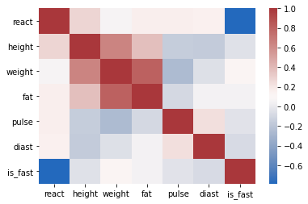

```python
import seaborn as sns

sns.heatmap(
    df.corr(),
    cmap=sns.color_palette('vlag', as_cmap=True)
);
```

Pokračovat můžeme párovými scatter ploty, kdy již využijeme přidanou přidaný znak "is_fast" k obarvení.

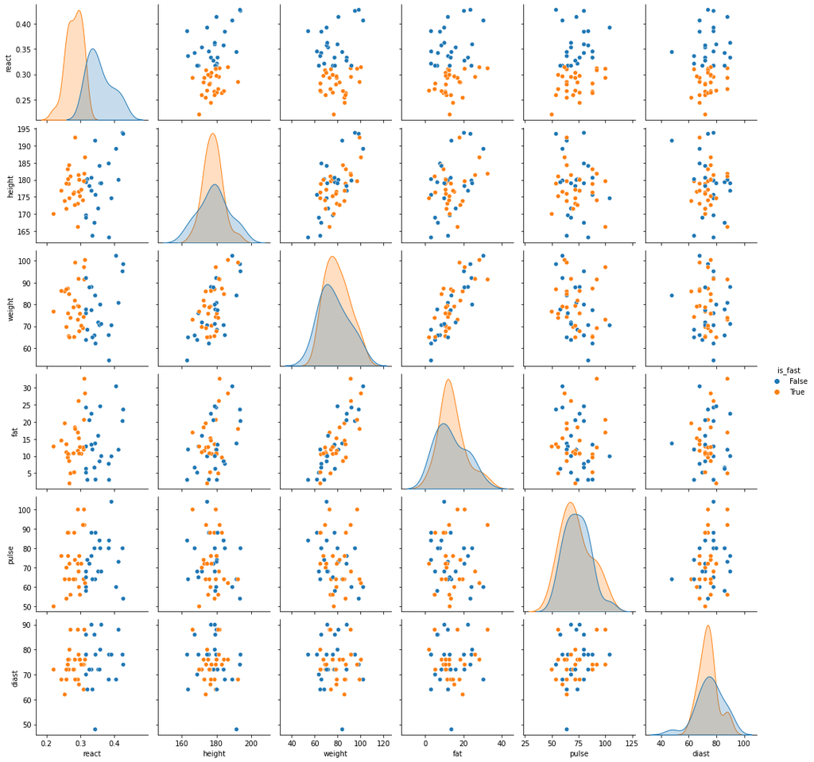

```python
sns.pairplot(df, hue='is_fast');
```

Podobně u grafu s paralelními osami, kde navíc použijeme standardizovaná data, abychom měli jednotné měřítko os.

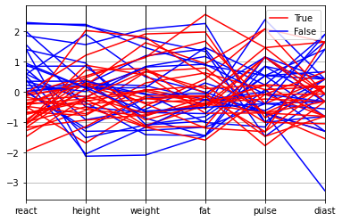

```python
pd.plotting.parallel_coordinates(
    normalized_df,
    class_column='is_fast',
    color=['red', 'blue']
);
```

Nakonec přidáme biplot hlavních komponent. Data používáme standardizovaná bez přidaného znaku a bez veličiny "react", abychom viděli, zda hlavní komponenty ze zbylých dat hledané skupiny neodhalí.

[output not shown]

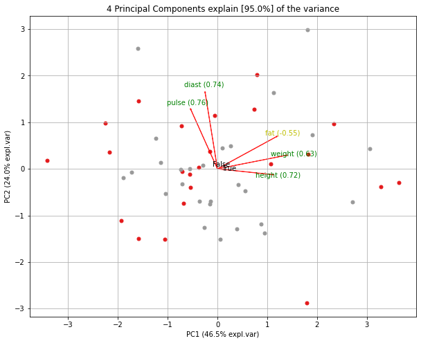

```python
from pca import pca

pca_df = normalized_df.set_index('is_fast').drop('react', axis=1)

model = pca()

results = model.fit_transform(
    normalized_df.set_index('is_fast').drop('react', axis=1)
)

model.biplot(legend=False);
```

## Interpretace

Z dat je vidět, že moc zajímavých vztahů mezi veličinou "react" a ostatními nemáme. Je to patrné z korelační matice (a heatmapy), kde jediná zajímavější korelace je s výškou, tj. "height". Pohled na párové scatter ploty a graf s paralelními osami také nic zajímavého o vztahu reakce s ostatním veličinám neříká.

Co se týče vztahů mezi ostatními veličinami, tak vidíme nepřekvapivý vztah mezi výškou, hmotností a podílem tuku. Tyto veličiny jsou mezi sebou poměrně silně korelované. Také asi nepřekvapí, že z nich je nejsilnější korelace mezi hmotností a podílem tuku. Nejslabší pak mezi výškou a podílem tuku. Linearita závislostí je pak dobře vidět na párových scatter plotech.

Trochu překvapivá může být záporná korelace mezi hmotností a pulsem. Obecně pak záporná korelace mezi tlakem a pulsem s předchozími třemi veličinami (s výjimkou tlaku a podílu tuku). Nicméně absolutní hodnoty korelací jsou poměrně malé, abychom z toho dělali nějaké závěry.

Zároveň je dobré říci, že na vysvětlení 95 % variance jsou potřeba celé 4 komponenty. Tedy, abychom zachovali podstatnou část variance, můžeme si dovolit snížit dimenzi pouze o 1. Můžeme tedy říci, že na data neexistuje nějaký obzvlášť dobrý pohled, oproti původnímu stavu.